# Reproducible Research Assignment Week 2

WW van Niekerk

10 March 2017

# Course Assignment: Week 2

## Step 1: Getting the data

I downloaded the file manualy and saved in my working directory, so I can just use the read.csv function to get the data

```r
activity <- read.csv("activity.csv",sep = ",",header = TRUE)
head(activity)
```

```
##   steps       date interval
## 1    NA 2012-10-01        0
## 2    NA 2012-10-01        5
## 3    NA 2012-10-01       10
## 4    NA 2012-10-01       15
## 5    NA 2012-10-01       20
## 6    NA 2012-10-01       25
```

I use the head data just to show the first 6 lines of the data.

## Step 2: Transform the data

I would like to use the tbl_df function to transform my data, so that I can use dplyr and tidyr packages.These packages makes clean and summarizing data alot easier.

```r
library(ggplot2)
library(dplyr)
library(tidyr)
activity <- tbl_df(activity)
activity
```

```
## # A tibble: 17,568 × 3
##    steps       date interval
##    <int>     <fctr>    <int>
## 1     NA 2012-10-01        0
## 2     NA 2012-10-01        5
## 3     NA 2012-10-01       10
## 4     NA 2012-10-01       15
## 5     NA 2012-10-01       20
## 6     NA 2012-10-01       25
## 7     NA 2012-10-01       30
## 8     NA 2012-10-01       35
## 9     NA 2012-10-01       40
## 10    NA 2012-10-01       45
## # ... with 17,558 more rows
```

I use the message = false so that the packages loaded messages are not displayed in the markdown file

Next I will remove all rows with NA values, as I do not want to use those observations.

```r
na <- is.na(activity[["steps"]])
activity <- activity[!na,]
sum(is.na(activity))
```

```
## [1] 0
```

I display the sum of the NA values in the activity table, the value is 0 because all the NA values was removed.

## Step 3: What is mean total number of steps taken per day?

### Calculate total number of steps taken per day

```r
restruc <- group_by(activity,date)
byday <- summarize(restruc, steps=sum(steps))
byday
```

```
## # A tibble: 53 × 2
##          date steps
##        <fctr> <int>
## 1  2012-10-02   126
## 2  2012-10-03 11352
## 3  2012-10-04 12116
## 4  2012-10-05 13294
## 5  2012-10-06 15420
## 6  2012-10-07 11015
## 7  2012-10-09 12811
## 8  2012-10-10  9900
## 9  2012-10-11 10304
## 10 2012-10-12 17382
## # ... with 43 more rows
```

I create a new table that summarizes the sum of the steps per day.

### Generate a histogram of total number of steps taken per day

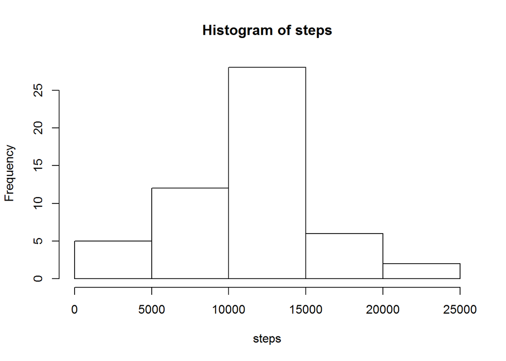

```r
with(byday,hist(steps))
```

Histogram of total number of steps per day displayed above

### Mean and median of total number of steps per day

```r
with(byday,summary(steps))
```

```
##    Min. 1st Qu.  Median    Mean 3rd Qu.    Max.
##      41    8841   10760   10770   13290   21190
```

I use the summarise function just to display a bit more information

## What is the activity pattern?

First I will summarize the number of steps by interval

```r
restuc2 <- group_by(activity,interval)
byinterval <- summarize(restuc2,steps=mean(steps))
byinterval
```

```
## # A tibble: 288 × 2
##    interval     steps
##       <int>     <dbl>
## 1         0 1.7169811
## 2         5 0.3396226
## 3        10 0.1320755
## 4        15 0.1509434
## 5        20 0.0754717
## 6        25 2.0943396
## 7        30 0.5283019
## 8        35 0.8679245
## 9        40 0.0000000
## 10       45 1.4716981
## # ... with 278 more rows
```

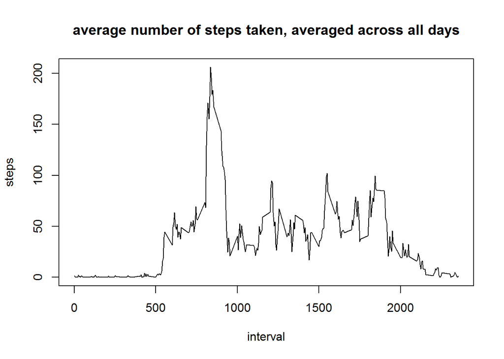

```r
with(byinterval,plot(interval,steps,type = "l",main = "average number of steps taken, averaged across all days"))
```

Next I wil display the max interval along with the average steps

```r
byinterval <- arrange(byinterval,steps)
tail(byinterval,1)
```

```
## # A tibble: 1 × 2
##   interval    steps
##      <int>    <dbl>
## 1      835 206.1698
```

## Imputing missing values

First I will get the original data set and report the amount of NA values

```r
activity2 <- read.csv("activity.csv",sep = ",",header = TRUE)
sum(is.na(activity2))
```

```
## [1] 2304
```

```r
for(i in 1:nrow(activity2)){
  test = activity2[i,1]
  if(is.na(test)){
    j = match(activity2[i,3],byinterval$interval)
    activity2[i,1]=byinterval$steps[j]
}
}
head(activity2)
```

```
##       steps       date interval
## 1 1.7169811 2012-10-01        0
## 2 0.3396226 2012-10-01        5
## 3 0.1320755 2012-10-01       10
## 4 0.1509434 2012-10-01       15
## 5 0.0754717 2012-10-01       20
## 6 2.0943396 2012-10-01       25
```

```r
sum(is.na(activity2))
```

```
## [1] 0
```

As seen in the 6 rows of activity2 all NA has been removed and if that is not proof enough the sum of NA values in activity2 is also shown as 0

I will use the same method as used above to compute the sum of total steps per day

```r
restruc3 <- group_by(activity2,date)
byday2 <- summarize(restruc3,steps=sum(steps))
byday2
```

```
## # A tibble: 61 × 2
##          date    steps
##        <fctr>    <dbl>
## 1  2012-10-01 10766.19
## 2  2012-10-02   126.00
## 3  2012-10-03 11352.00
## 4  2012-10-04 12116.00
## 5  2012-10-05 13294.00
## 6  2012-10-06 15420.00
## 7  2012-10-07 11015.00
## 8  2012-10-08 10766.19
## 9  2012-10-09 12811.00
## 10 2012-10-10  9900.00
## # ... with 51 more rows
```

Next histogram plot as well as mean and median of total steps taken per day

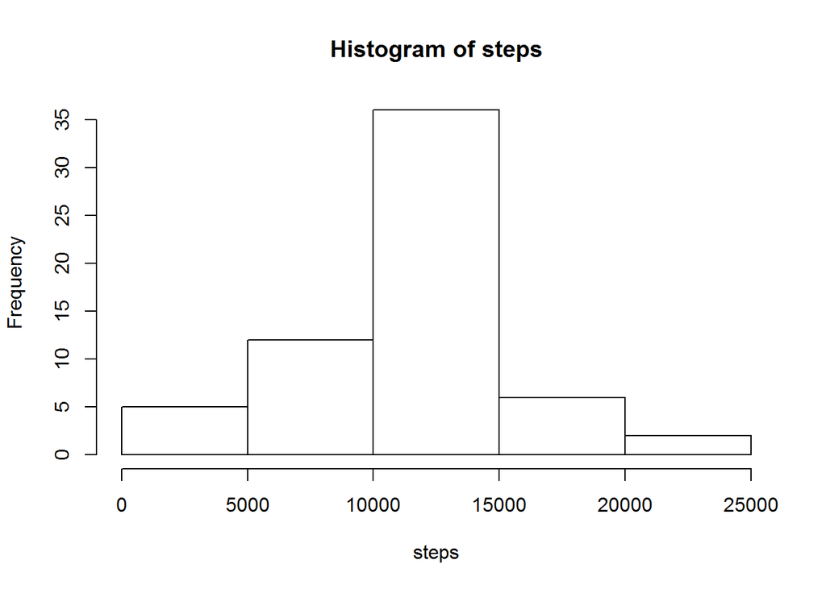

```r
with(byday2,hist(steps))
```

```r
summary(byday2$steps)
```

```
##    Min. 1st Qu.  Median    Mean 3rd Qu.    Max.
##      41    9819   10770   10770   12810   21190
```

```r
summary(byday$steps)
```

```
##    Min. 1st Qu.  Median    Mean 3rd Qu.    Max.
##      41    8841   10760   10770   13290   21190
```

## Are there differences in activity patterns between weekdays and weekends?

First I will add a column to the activity2 column which specifies wheather a date is weekend or weekday

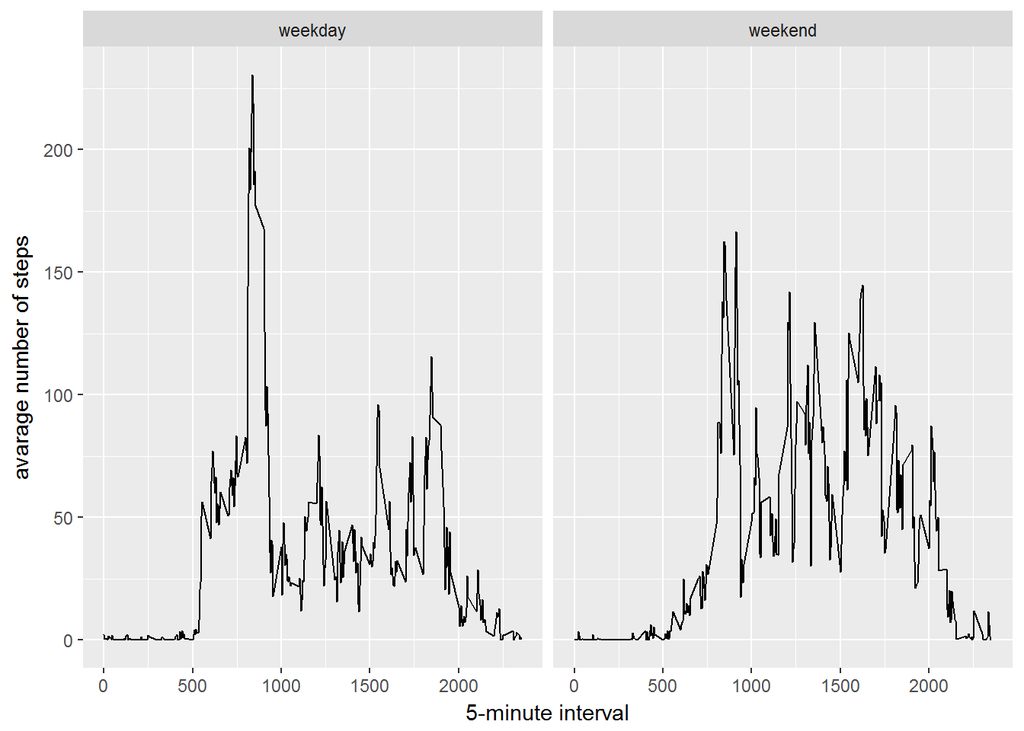

```r
activity2$dateType <-  ifelse(as.POSIXlt(activity2$date)$wday %in% c(0,6), 'weekend', 'weekday')
activity3 <- aggregate(steps ~ interval + dateType, data=activity2, mean)
ggplot(activity3, aes(interval, steps)) +
    geom_line() +
    facet_grid(.~ dateType ) +
    xlab("5-minute interval") +
    ylab("avarage number of steps")
```